# Vacation Package Project

### Prod Taken

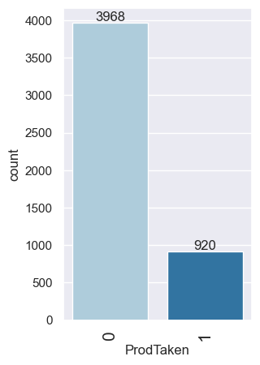

```python
labeledbarplot(df, 'ProdTaken')
```

##### Observations

Almost 4 times as many people did not purchase a product as those who did.

### Type of Contact

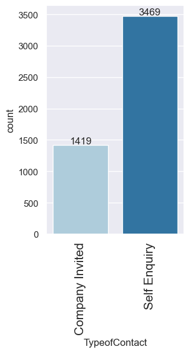

```python
labeledbarplot(df, 'TypeofContact')
```

##### Observations

Roughly double the number of people in our dataset contacted by self enquiry than Company Invited

### City Tier

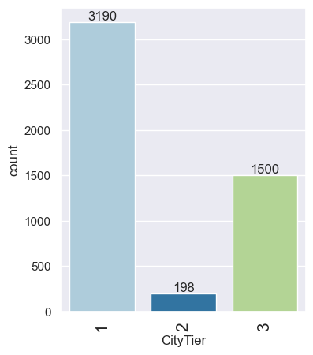

```python
labeledbarplot(df, 'CityTier')
```

##### Observations

Most people do not live in a tier 2 city, and double the number of people live in Tier 1 cities than Tier 3

### Occupation

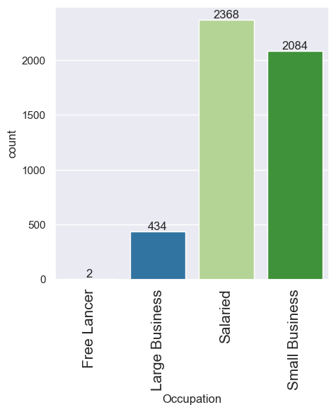

```python
labeledbarplot(df, 'Occupation')
```

##### Observations

- Most individuals are Salaried or Small Business
- Free Lancer has no significant bearing on our dataset
- Free Lancer and Large business should merge to prevent overfit, as an "Other" category

### Gender

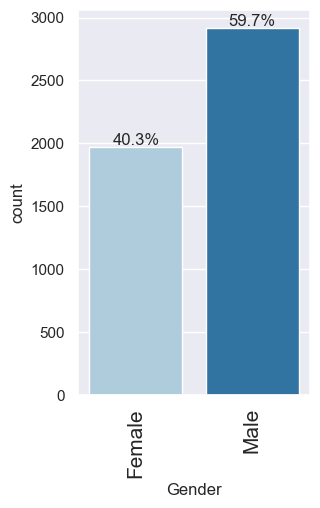

```python
labeledbarplot(df, 'Gender', perc= True )
```

##### Observations

There are more men than women in this dataset, but it is much more representative than the data we normally see. There are roughly 1000 more men than women, or about a 60/40 split between men and women

### Number of People Visiting

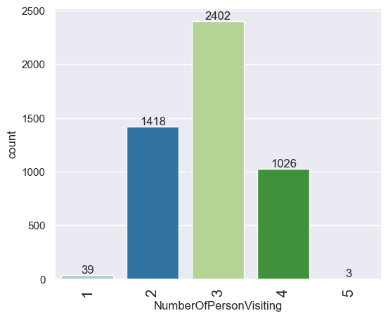

```python
labeledbarplot(df, 'NumberOfPersonVisiting')
```

##### Observations

- This dataset is extremely close to a normal distribution
- 1 and 5 should be combined into an "other" category to prevent overfit, or 1+2 and 4+5 merge

### Number of Followups

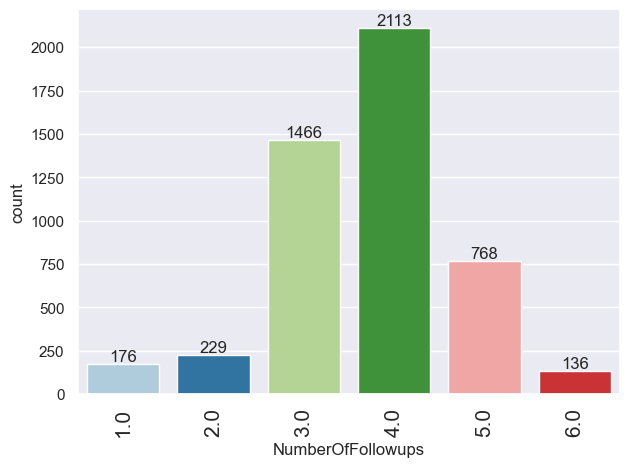

```python
labeledbarplot(df, 'NumberOfFollowups')
```

##### Observations

- This again seems normally distributed
- Either 1, 2, and six should merge into "other", or more likely, one and two merge, and five and six merge.

### Product Pitched

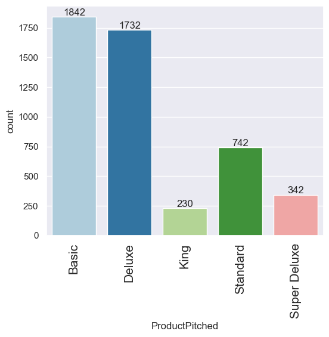

```python
labeledbarplot(df, 'ProductPitched')
```

##### Observations

- This is not a normal distribution, with Basic and Deluxe topping the chart
- Basic, Deluxe, and Standard should remain the same while King and Super Deluxe merge into an "Other Category

### Preferred Property Star

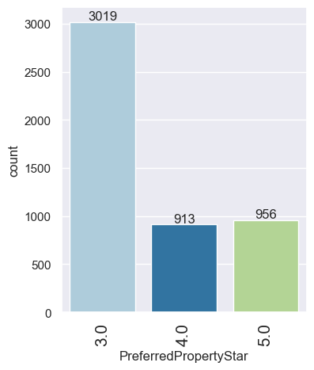

```python
labeledbarplot(df, 'PreferredPropertyStar')
```

##### Observations

There are triple the number of people who prefer 3 star properties to 4 or 5

### Marital Status

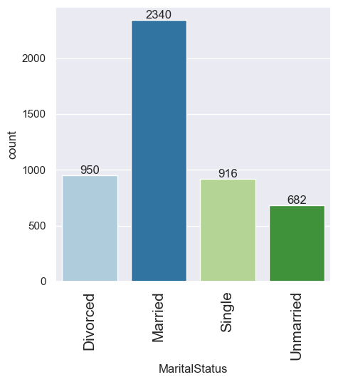

```python
labeledbarplot(df, 'MaritalStatus')
```

##### Observations

- Married has double the number of records than other categories
- It is probbaly a good idea to simplify just to "Married" or "Unmarried"

### Number of Trips

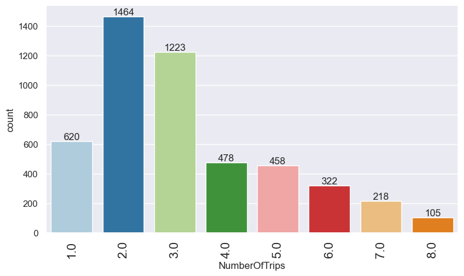

```python
labeledbarplot(df, 'NumberOfTrips')
```

##### Observations

- This is not normally distributed, 2 and 3 have double the number of other records
- Merging categories for 6, 7, and 8 into "6 and Above" seems like a good idea to prevent overfit

### Passport

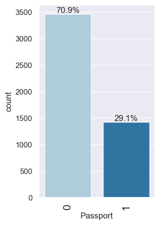

```python
labeledbarplot(df, 'Passport', perc = True)
```

##### Observations

70% of individuals in our dataset do not have a passport, which may significantly impact our sales of overseas packages

### Pitch Satisfaction Score

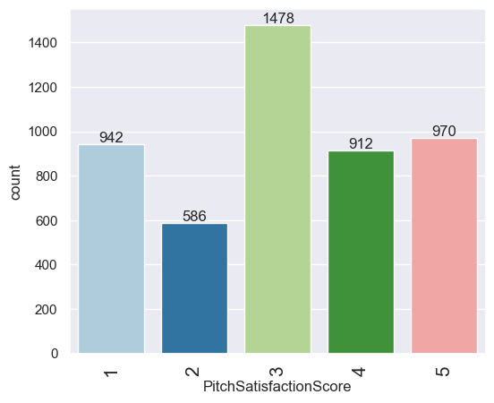

```python
labeledbarplot(df, 'PitchSatisfactionScore')
```

##### Observations

Our pitch satisfaction score records seem to be all fairly statistically significant and fairly normal in distribution. 3 seems to have the highest with roughly 500 records more than our other data. 2 is the lowest with a thousnad less records than 3

### Car Ownership

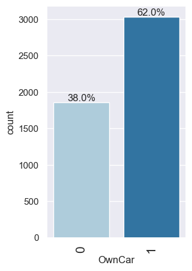

```python
labeledbarplot(df, 'OwnCar', perc =True)
```

##### Observations

Roughly 40% of people in our dataset did not own a car

### Number of Children Visiting

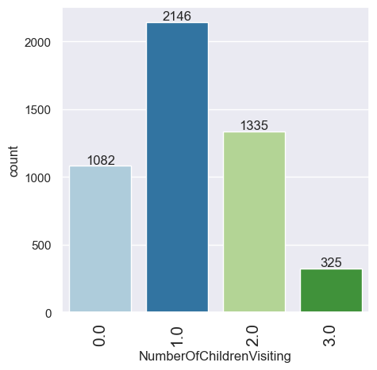

```python
labeledbarplot(df, 'NumberOfChildrenVisiting')
```

##### Observations

- Fairly normal distribution
- Combine 2 and 3 together to make 2+
- May be a good idea to merge with other datasets, such as NumberofPersonVisiting to create a simple category of if that group has children or not.

### Designation

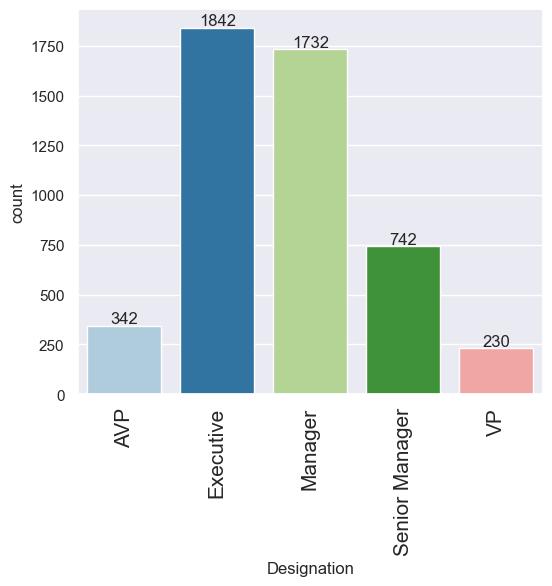

```python
labeledbarplot(df, 'Designation')
```

##### Observations

- This is a fairly normal distribution
- I think there are too many categories for this, combining AVP, VP, and Senior Manager into just "other" makes sense, or AVP and VP can be combined into executive, and senior manager to manager

## Bivariate Analysis

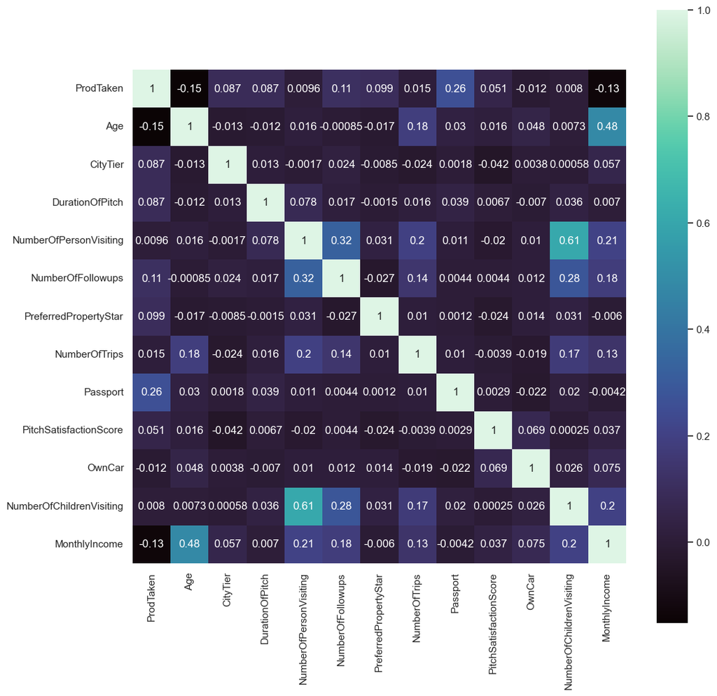

```python
fig, ax = plt.subplots(figsize=(12,12))
sns.heatmap(df.corr(), annot = True, cmap = "mako", square = True, ax = ax)
```

##### Observations

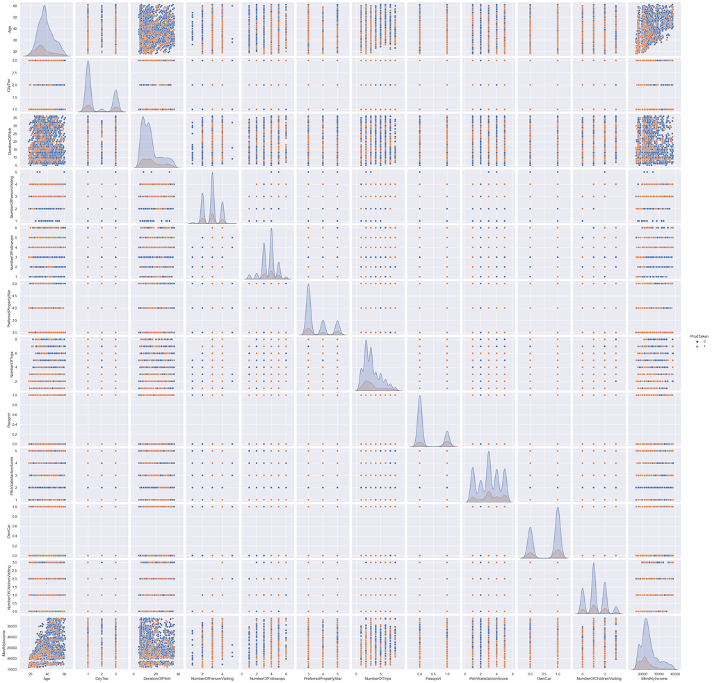

```python
sns.pairplot(df, diag_kind="kde", hue = 'ProdTaken')
```

### Numeric Means by ProdTaken

```python
df.groupby(['ProdTaken']).mean().T
```

| ProdTaken | 0 | 1 |
| --- | --- | --- |
| Age | 38.223286 | 34.685870 |
| CityTier | 1.615927 | 1.819565 |
| DurationOfPitch | 14.999496 | 16.781522 |
| NumberOfPersonVisiting | 2.901714 | 2.919565 |
| NumberOfFollowups | 3.657510 | 3.942391 |
| PreferredPropertyStar | 3.540071 | 3.741304 |
| NumberOfTrips | 3.203125 | 3.268478 |
| Passport | 0.233871 | 0.536957 |
| PitchSatisfactionScore | 3.044355 | 3.223913 |
| OwnCar | 0.622984 | 0.608696 |
| NumberOfChildrenVisiting | 1.181452 | 1.198913 |
| MonthlyIncome | 23871.228831 | 22138.016304 |

##### Observations

- People who purchase the packages are younger
- In general, people who purchased the package had a 17 minute pitch
- People who purchased a package had more followups than those who didn't
- People who purchased a package preferred higher property stars
- Passport holders were more likely to purchase a package
- Those more satisfied with the pitch were more likely to purchase a package
- Car owners were slightly less likely to purchase a package
- Those that made a lower income were more likely to purchase a package

### Numeric Columns By ProdTaken

#### Age

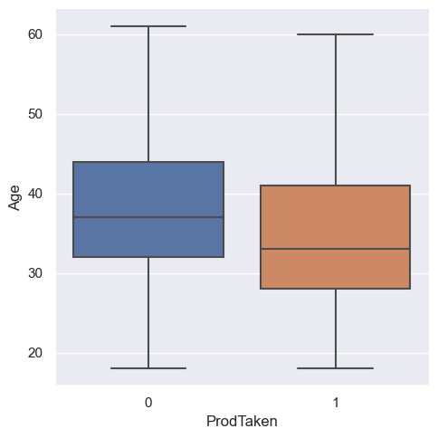

```python
stackedbox(df, 'Age', 'ProdTaken')
```

```python
minmeanmax(df, 'Age', 'ProdTaken')
```

```
Not Purchased Min Mean and Max:

 Min: 18.0
 Mean: 38.223286
 Max: 61.0

Purchased Min Mean and Max:

 Min: 18.0
 Mean: 34.68587
 Max: 60.0
```

##### Observations

Those who purchased a package were slightly younger all around, with a lower median, mean, and Q3 point than those who didn't interestingly though they had the same minimum, but those who purchased had a lower maximum

#### Duration of Pitch

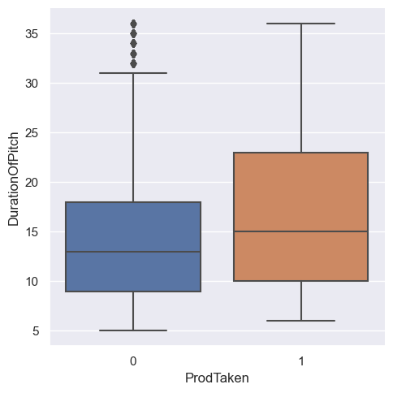

```python
stackedbox(df, 'DurationOfPitch', 'ProdTaken')
```

```python
minmeanmax(df, 'DurationOfPitch', 'ProdTaken')
```

```
Not Purchased Min Mean and Max:

 Min: 5.0
 Mean: 14.999496
 Max: 36.0

Purchased Min Mean and Max:

 Min: 6.0
 Mean: 16.781522
 Max: 36.0
```

##### Observations

- Those that purchased packages had a longer pitch in every way except for the maximum
- Those that didn't have some outliers due to having a lower mean, median, a smaller IQR, and a lower Q3 point
- If we saw significant correlation with duration of pitch it might be worth removing those errant values, but for now we will be leaving them

#### Monthly Income

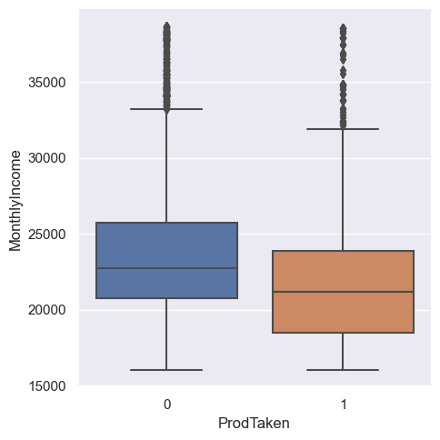

```python
stackedbox(df, 'MonthlyIncome', 'ProdTaken')
```

```python
minmeanmax(df, 'MonthlyIncome', 'ProdTaken')
```

```
Not Purchased Min Mean and Max:

 Min: 16051.0
 Mean: 23871.228831
 Max: 38677.0

Purchased Min Mean and Max:

 Min: 16009.0
 Mean: 22138.016304
 Max: 38537.0
```

##### Observations

- We saw above that MonthlyIncome and Prodtaken had a slight negative correlation
- Given the values we see here, with a clear lower min, Q1, mean, median, Q3, and max the outliers are causing issues with that correlation
- I do not wish to remove or cap the outliers, as they are likely accurate, but doing a log scale probably helps us build a better model with the changes to the structure likely bringing in some of those outliers

### Categorical Columns by ProdTaken

```python
# df.head(5)
```

[output not shown]

#### Type of Contact

```
ProdTaken           0    1   All
TypeofContact
All              3968  920  4888
Self Enquiry     2859  610  3469
Company Invited  1109  310  1419
-------------------------------------------------------------------------------------------------------------------
ProdTaken               0         1
TypeofContact
Company Invited  0.781536  0.218464
Self Enquiry     0.824157  0.175843
```

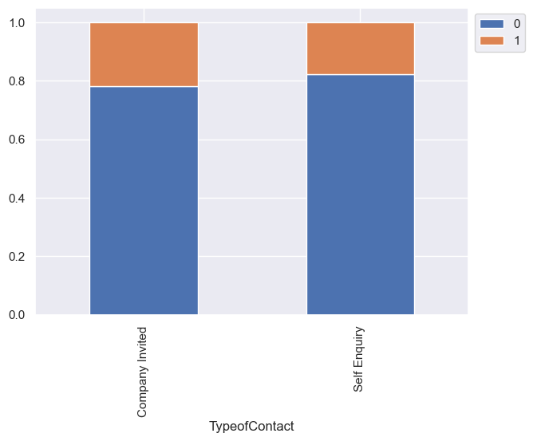

```python
stackedbarplot(df, 'TypeofContact', 'ProdTaken')
```

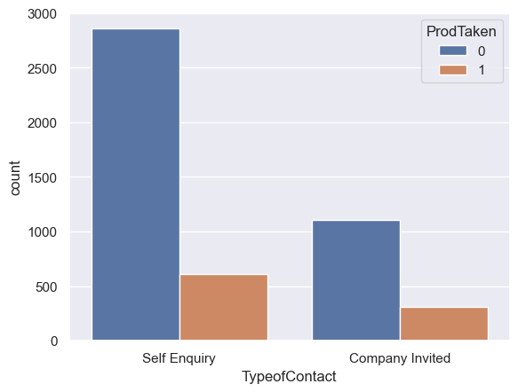

```python
sns.countplot(data= df, x='TypeofContact', hue = 'ProdTaken')
```

##### Observations

- Self Enquiries make up the majority of our data, and consequently share the most accepted products
- If you were invited by a company you were slightly more likely to purchase the product. with a little over 20% of customers purchasing the product

#### City Tier

```
ProdTaken     0    1   All
CityTier
All        3968  920  4888
1          2670  520  3190
3          1146  354  1500
2           152   46   198
-------------------------------------------------------------------------------------------------------------------
ProdTaken         0         1
CityTier
3          0.764000  0.236000
2          0.767677  0.232323
1          0.836991  0.163009
```

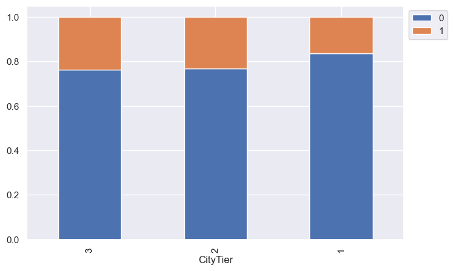

```python
stackedbarplot(df, 'CityTier', 'ProdTaken')
```

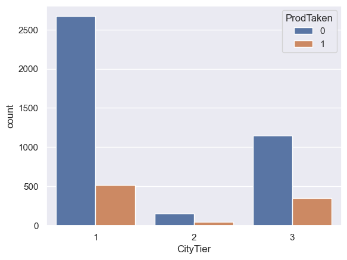

```python
sns.countplot(data= df, x='CityTier', hue = 'ProdTaken')
```

##### Obserations

- Tier 2 and 3 cities purchased products at a much higher rate than Tier 1 Cities
- Tier 1 Cities were offered many more packages than Tier 2 and 3 cities
- Tier 1 cities purchased the most packages, but Tier 3 is close with significantly fewer products offered
- tier 2 cities have very few records, so observations may be more skewed than Tier 1 or Tier 3 cities

#### Occupation

```
ProdTaken          0    1   All
Occupation
All             3968  920  4888
Salaried        1954  414  2368
Small Business  1700  384  2084
Large Business   314  120   434
Free Lancer        0    2     2
-------------------------------------------------------------------------------------------------------------------
ProdTaken              0         1
Occupation
Free Lancer     0.000000  1.000000
Large Business  0.723502  0.276498
Small Business  0.815739  0.184261
Salaried        0.825169  0.174831
```

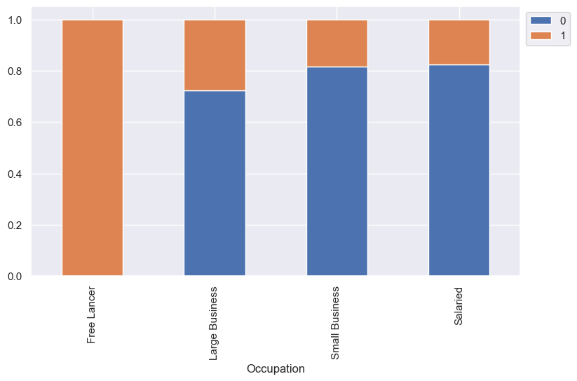

```python
stackedbarplot(df, 'Occupation', 'ProdTaken')
```

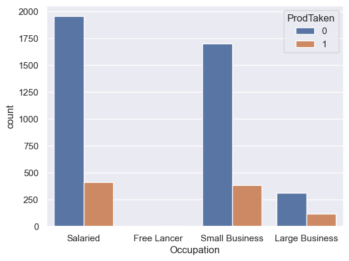

```python
sns.countplot(data= df, x='Occupation', hue = 'ProdTaken')
```

```python
df.loc[df['Occupation'] == 'Free Lancer']
```

|  | ProdTaken | Age | TypeofContact | CityTier | DurationOfPitch | Occupation | Gender | NumberOfPersonVisiting | NumberOfFollowups | ProductPitched | PreferredPropertyStar | MaritalStatus | NumberOfTrips | Passport | PitchSatisfactionScore | OwnCar | NumberOfChildrenVisiting | Designation | MonthlyIncome |
| --- | --- | --- | --- | --- | --- | --- | --- | --- | --- | --- | --- | --- | --- | --- | --- | --- | --- | --- | --- |
| 2 | 1 | 37.0 | Self Enquiry | 1 | 8.0 | Free Lancer | Male | 3 | 4.0 | Basic | 3.0 | Single | 7.0 | 1 | 3 | 0 | 0.0 | Executive | 17090.0 |
| 2446 | 1 | 38.0 | Self Enquiry | 1 | 9.0 | Free Lancer | Male | 4 | 5.0 | Basic | 3.0 | Single | 8.0 | 1 | 3 | 0 | 1.0 | Executive | 20768.0 |

##### Observations

- Free Lancers take 100% of the packages they are offered, but there are exactly two records for freelancers.
- Removing the Free Lancer records and/or changing the label to one of the others will help us prevent disrupting the model
- Of the other models, large businesses took 30% of the packages offered, but had the smallest count of packages bought
- Small Business and Salaried both had a close purchase rate of about 20%, but salaried were offered more packages for roughly the same count

#### Gender

```
ProdTaken     0    1   All
Gender
All        3968  920  4888
Male       2338  578  2916
Female     1630  342  1972
-------------------------------------------------------------------------------------------------------------------
ProdTaken         0         1
Gender
Male       0.801783  0.198217
Female     0.826572  0.173428
```

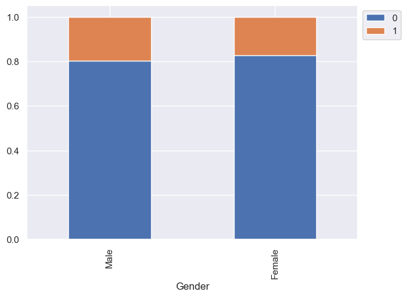

```python
stackedbarplot(df, 'Gender', 'ProdTaken')
```

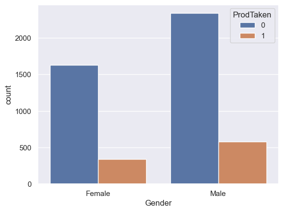

```python
sns.countplot(data= df, x='Gender', hue = 'ProdTaken')
```

##### Observations

- Men purchased packages at a slightly higher rate than women
- Men were offered significantly more packages than women were
- Our resultant model may be slightly skewed to view men more favorably than women in package sales

#### Number of Persons Visiting

```
ProdTaken                  0    1   All
NumberOfPersonVisiting
All                     3968  920  4888
3                       1942  460  2402
2                       1151  267  1418
4                        833  193  1026
1                         39    0    39
5                          3    0     3
-------------------------------------------------------------------------------------------------------------------
ProdTaken                      0         1
NumberOfPersonVisiting
3                       0.808493  0.191507
2                       0.811707  0.188293
4                       0.811891  0.188109
1                       1.000000  0.000000
5                       1.000000  0.000000
```

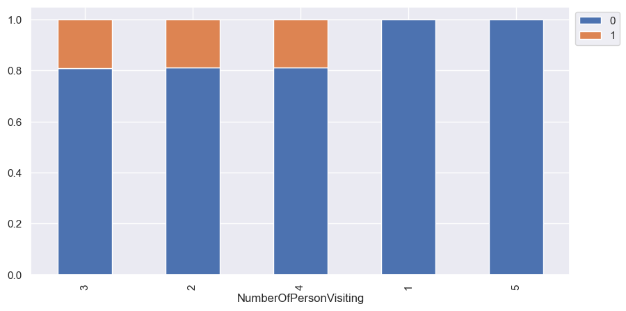

```python
stackedbarplot(df, 'NumberOfPersonVisiting', 'ProdTaken')
```

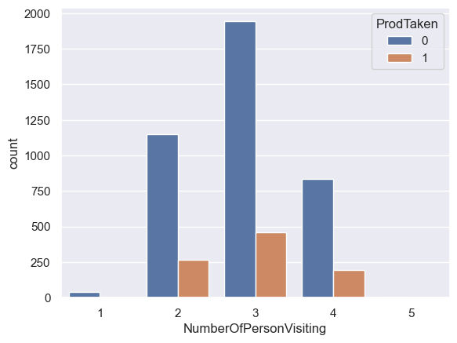

```python
sns.countplot(data= df, x='NumberOfPersonVisiting', hue = 'ProdTaken')
```

##### Observations

- 1 and 5 people visiting did not purchase any packages
- 2,3, and 4 person groups all purchased about 20% of the packages they were offered
- There are 39 rows for 1 and 3 rows for 5, removing the rows outright is a bad idea
- Grouping 1 and 2, and 4 and 5 seems like a good idea, that does cause a slight negative skew to both, but overall they should stay roughly the same

#### Number of Followups

```
ProdTaken             0    1   All
NumberOfFollowups
All                3968  920  4888
4.0                1726  387  2113
3.0                1222  244  1466
5.0                 577  191   768
6.0                  82   54   136
2.0                 205   24   229
1.0                 156   20   176
-------------------------------------------------------------------------------------------------------------------
ProdTaken                 0         1
NumberOfFollowups
6.0                0.602941  0.397059
5.0                0.751302  0.248698
4.0                0.816848  0.183152
3.0                0.833561  0.166439
1.0                0.886364  0.113636
2.0                0.895197  0.104803
```

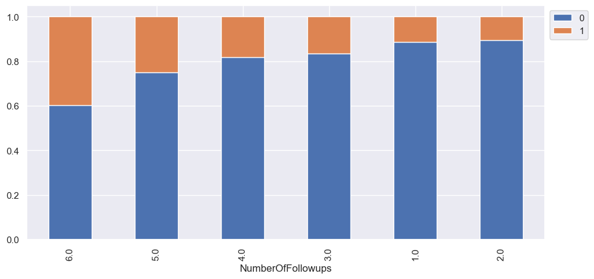

```python
stackedbarplot(df, 'NumberOfFollowups', 'ProdTaken')
```

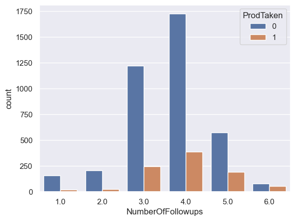

```python
sns.countplot(data= df, x='NumberOfFollowups', hue = 'ProdTaken')
```

##### Observations

- Six had the highest percentage of people purchase a package at roughly 40%
- One and two had the lowest percentage of takers with around 10% each
- There is a pretty significant correlation between number of followups and ProdTaken

#### Product Pitched

```
ProdTaken          0    1   All
ProductPitched
All             3968  920  4888
Basic           1290  552  1842
Deluxe          1528  204  1732
Standard         618  124   742
King             210   20   230
Super Deluxe     322   20   342
-------------------------------------------------------------------------------------------------------------------
ProdTaken              0         1
ProductPitched
Basic           0.700326  0.299674
Standard        0.832884  0.167116
Deluxe          0.882217  0.117783
King            0.913043  0.086957
Super Deluxe    0.941520  0.058480
```

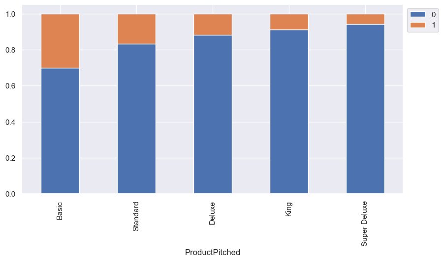

```python
stackedbarplot(df, 'ProductPitched', 'ProdTaken')
```

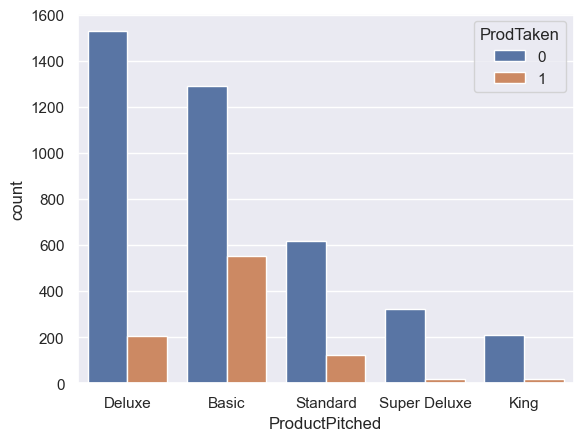

```python
sns.countplot(data= df, x='ProductPitched', hue = 'ProdTaken')
```

##### Observations

- Basic Performed the Best in terms of sales with 30% of pitched products being sold
- The Super Deluxe performed the absolute worst, with just 6% of those that were pitched the product purchasing it
- The Deluxe was pitched a similar number of times to Basic, but performed far worse at just 10% of those having the product pitched purchasing the product
- There is a fairly strong negative correlation between products pitched and ProdTaken (assuming Super Deluxe or King are Higher numbers and Basic is the lowest)

#### Preferred Property Star

```
ProdTaken                 0    1   All
PreferredPropertyStar
All                    3968  920  4888
3.0                    2531  488  3019
5.0                     706  250   956
4.0                     731  182   913
-------------------------------------------------------------------------------------------------------------------
ProdTaken                     0         1
PreferredPropertyStar
5.0                    0.738494  0.261506
4.0                    0.800657  0.199343
3.0                    0.838357  0.161643
```

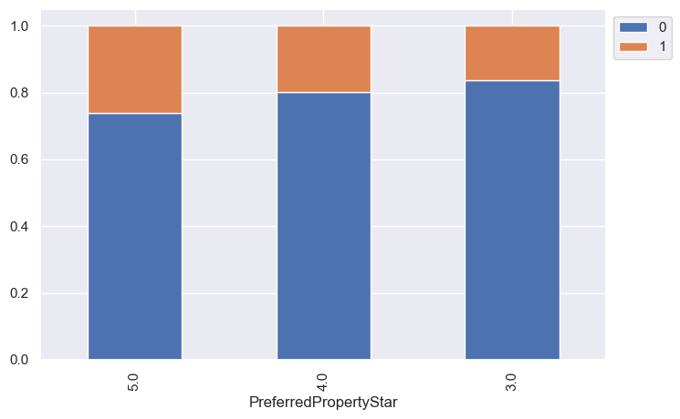

```python
stackedbarplot(df, 'PreferredPropertyStar', 'ProdTaken')
```

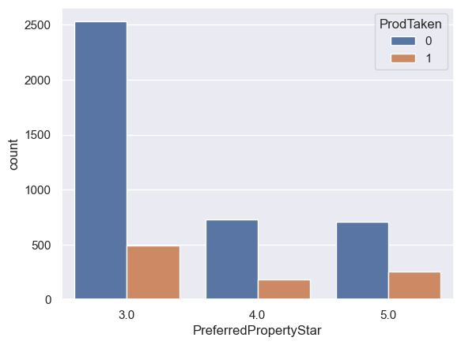

```python
sns.countplot(data= df, x='PreferredPropertyStar', hue = 'ProdTaken')
```

##### Observations

- 3 was preferred vastly more often over 4 and 5 star properties
- People who preferred 3, purchased a package only 16% of the time
- 4 and 5 were preferred by roughly an equal number of customers
- people who preferred 5 star properties purchased a packages 26% of the time, a massive leap of those that preferred 3 stars
- There is a positive correlation between property star and prodtaken

#### Marital Status

```
ProdTaken         0    1   All
MaritalStatus
All            3968  920  4888
Married        2014  326  2340
Single          612  304   916
Unmarried       516  166   682
Divorced        826  124   950
-------------------------------------------------------------------------------------------------------------------
ProdTaken             0         1
MaritalStatus
Single         0.668122  0.331878
Unmarried      0.756598  0.243402
Married        0.860684  0.139316
Divorced       0.869474  0.130526
```

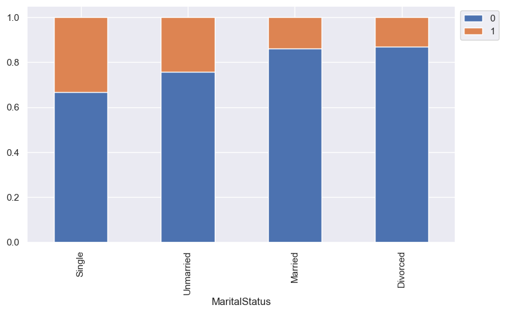

```python
stackedbarplot(df, 'MaritalStatus', 'ProdTaken')
```

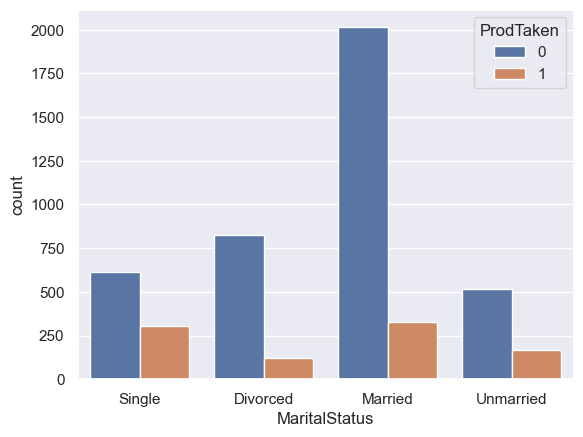

```python
sns.countplot(data= df, x='MaritalStatus', hue = 'ProdTaken')
```

#### Observations

- Single people were by far the most likely to purchase a package, with 33% of individuals in that group purchasing a package
- Those that are married and divorced, the highest number of records in our dataset were the *least* likely to purchase a package at 14 and 13 percent each
- Single individuals have a similar count of package takers to married despite being vastly underrepresented in our dataset
- Unmarried individuals also had a fairly high percentage of takers with 24% buyinh a package
- These seems to be a strong correlation between those that have never married, and products being purchased

#### Number of Trips

```
ProdTaken         0    1   All
NumberOfTrips
All            3968  920  4888
2.0            1165  299  1464
3.0             992  231  1223
1.0             508  112   620
6.0             258   64   322
5.0             396   62   458
7.0             156   62   218
4.0             417   61   478
8.0              76   29   105
-------------------------------------------------------------------------------------------------------------------
ProdTaken             0         1
NumberOfTrips
7.0            0.715596  0.284404
8.0            0.723810  0.276190
2.0            0.795765  0.204235
6.0            0.801242  0.198758
3.0            0.811120  0.188880
1.0            0.819355  0.180645
5.0            0.864629  0.135371
4.0            0.872385  0.127615
```

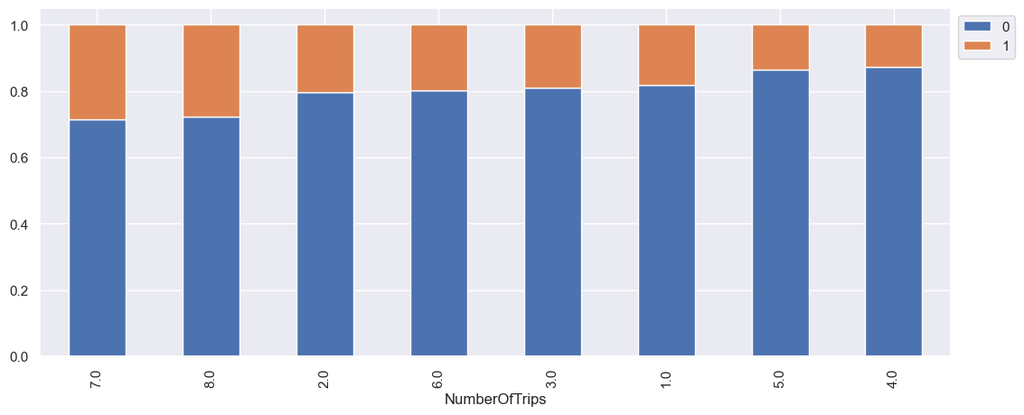

```python
stackedbarplot(df, 'NumberOfTrips', 'ProdTaken')
```

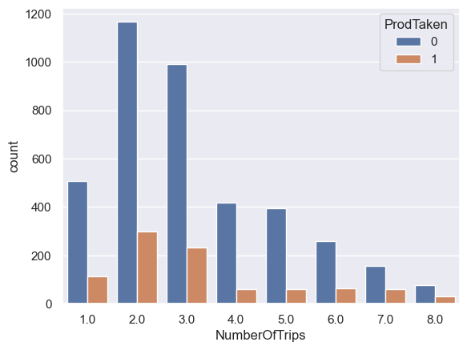

```python
sns.countplot(data= df, x='NumberOfTrips', hue = 'ProdTaken')
```

##### Observations

- 7 and 8 top the list in terms of shares of packages sold, with roughly 28% each
- 1, 2, 3, and 6 sit in the middle around 20%
- 4 and 5 are the lowest with roughly 13% each
- There is a moderate correlation between number of trips and purchasing products
- Given the number of different categories, grouping 6 and above seems like a good idea, due to model overfit, however, the dataset is also currently numeric so this may be a bad idea

#### Passport

```
ProdTaken     0    1   All
Passport
All        3968  920  4888
1           928  494  1422
0          3040  426  3466
-------------------------------------------------------------------------------------------------------------------
ProdTaken         0         1
Passport
1          0.652602  0.347398
0          0.877092  0.122908
```

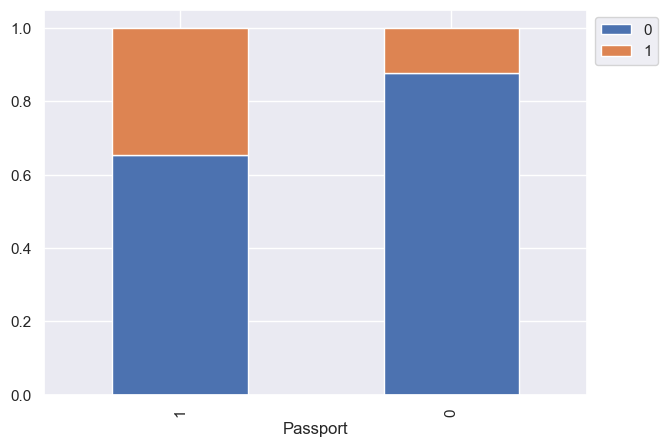

```python
stackedbarplot(df, 'Passport', 'ProdTaken')
```

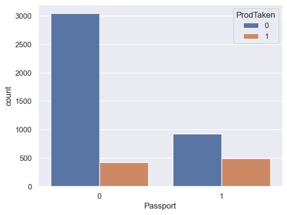

```python
sns.countplot(data= df, x='Passport', hue = 'ProdTaken')
```

##### Observation

- 35% of people who had a passport purchased a product vs 12% if they did not posses a passport
- There is a strong correlation between passport ownership and vacation taking, but passport owners are a smaller part of our dataset

#### Pitch Satisfaction Score

```
ProdTaken                  0    1   All
PitchSatisfactionScore
All                     3968  920  4888
3                       1162  316  1478
5                        760  210   970
4                        750  162   912
1                        798  144   942
2                        498   88   586
-------------------------------------------------------------------------------------------------------------------
ProdTaken                      0         1
PitchSatisfactionScore
5                       0.783505  0.216495
3                       0.786198  0.213802
4                       0.822368  0.177632
1                       0.847134  0.152866
2                       0.849829  0.150171
```

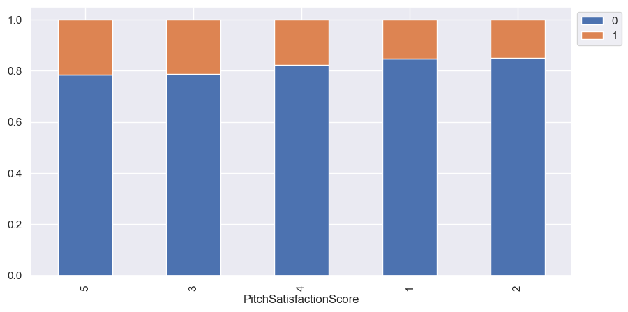

```python
stackedbarplot(df, 'PitchSatisfactionScore', 'ProdTaken')
```

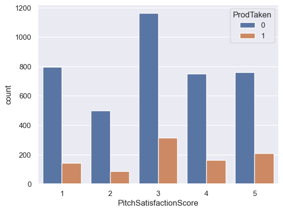

```python
sns.countplot(data= df, x='PitchSatisfactionScore', hue = 'ProdTaken')
```

##### Observations

- 3 and 5 top the list for packages purchased at roughly 20%, while 1 and 2 sit at the bottom with 15%
- 4 sits in the middle with 18% purchasing a package
- There is a weak correlation between pitch satisfaction and product purchase, but its hardly there

#### Own Car

```
ProdTaken     0    1   All
OwnCar
All        3968  920  4888
1          2472  560  3032
0          1496  360  1856
-------------------------------------------------------------------------------------------------------------------
ProdTaken         0         1
OwnCar
0          0.806034  0.193966
1          0.815303  0.184697
```

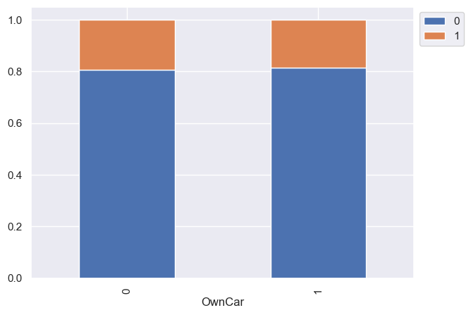

```python
stackedbarplot(df, 'OwnCar', 'ProdTaken')
```

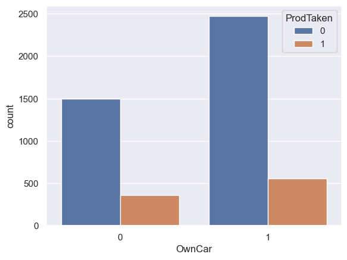

```python
sns.countplot(data= df, x='OwnCar', hue = 'ProdTaken')
```

##### Observations

- There appears to be almost no correlation between car ownership and product purchase
- We can probably drop this column in feature engineering, due to only a 0.9% difference between purchase rates

#### Number of Children Visiting

```
ProdTaken                    0    1   All
NumberOfChildrenVisiting
All                       3968  920  4888
1.0                       1747  399  2146
2.0                       1082  253  1335
0.0                        880  202  1082
3.0                        259   66   325
-------------------------------------------------------------------------------------------------------------------
ProdTaken                        0         1
NumberOfChildrenVisiting
3.0                       0.796923  0.203077
2.0                       0.810487  0.189513
0.0                       0.813309  0.186691
1.0                       0.814073  0.185927
```

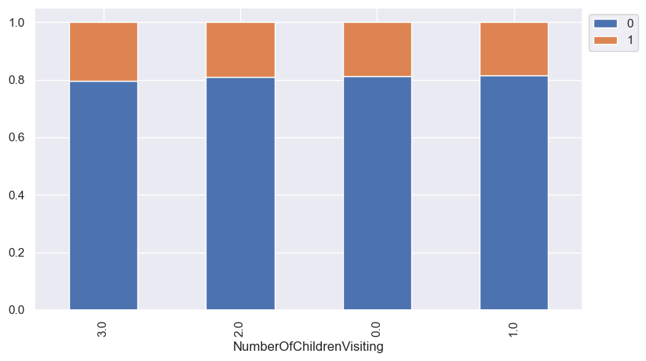

```python
stackedbarplot(df, 'NumberOfChildrenVisiting', 'ProdTaken')
```

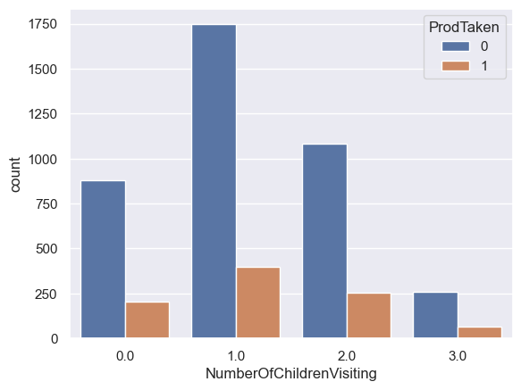

```python
sns.countplot(data= df, x='NumberOfChildrenVisiting', hue = 'ProdTaken')
```

##### Observations

- This again had a very small variance in product purchase rates, only deviating between 18.6% and 20.3%, or a 1.7% difference
- We can likely drop this entire column to prevent model overfit

#### Designation

```
ProdTaken          0    1   All
Designation
All             3968  920  4888
Executive       1290  552  1842
Manager         1528  204  1732
Senior Manager   618  124   742
AVP              322   20   342
VP               210   20   230
-------------------------------------------------------------------------------------------------------------------
ProdTaken              0         1
Designation
Executive       0.700326  0.299674
Senior Manager  0.832884  0.167116
Manager         0.882217  0.117783
VP              0.913043  0.086957
AVP             0.941520  0.058480
```

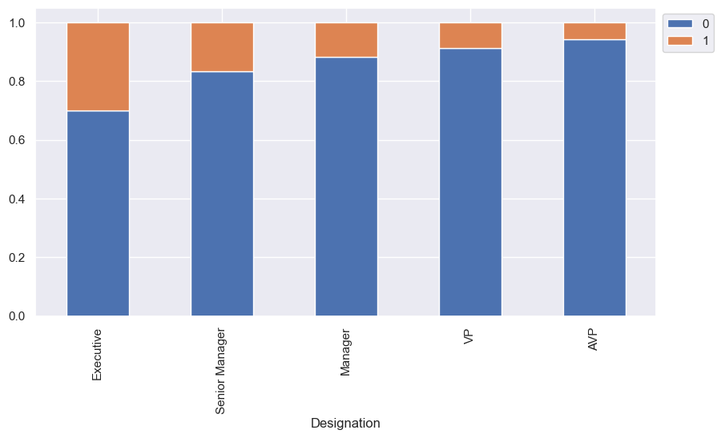

```python
stackedbarplot(df, 'Designation', 'ProdTaken')
```

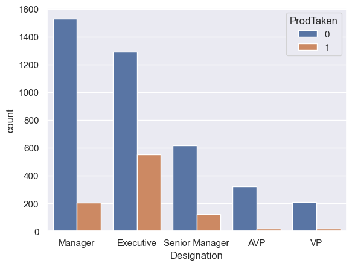

```python
sns.countplot(data= df, x='Designation', hue = 'ProdTaken')
```

###### Observations

- Executives were far and away the most likely to purchase a package at 30%
- The next Highest was Senior Manager at 17%, almost half of the Executive numbers
- AVP was the lowest with just 5% purchasing a package
- Assuming the designation is supposed to be ordered Manager, Senior Manager, AVP, VP, Executive, there doesn't seem to be a strong correlation in the data, but there is something to senior managers and executives having a higher rate, that the data should be kept
- Grouping AVP and VP is a good idea

### Multivariate Analysis of Different Features

#### Pointplot of Income, Number of Trips, and Product Taken

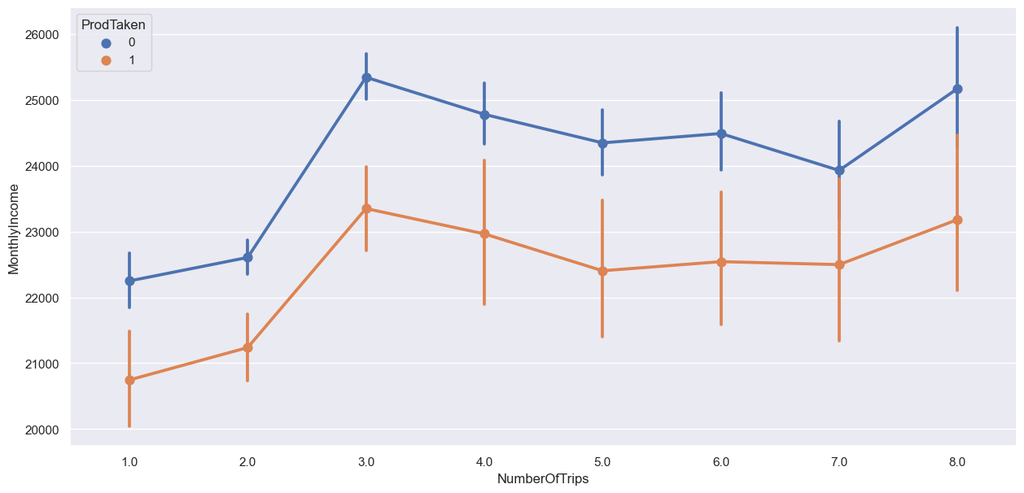

```python
plt.figure(figsize=(15, 7))
sns.pointplot(x = 'NumberOfTrips', y='MonthlyIncome', data=df, hue = 'ProdTaken')
```

##### Observations

The more you made, the less likely you were to buy any package, but the data seemed pretty similar in the variance of income by number of trips, with a major leap up from 2 trips a year to 3 in income

#### PointPlot of Income, Designation, and Product Taken

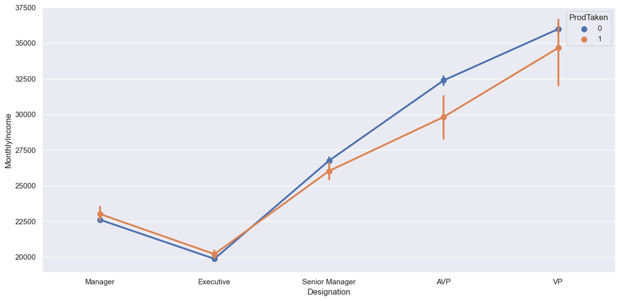

```python
plt.figure(figsize=(15, 7))
sns.pointplot(x = 'Designation', y='MonthlyIncome', data=df, hue = 'ProdTaken')
```

##### Observations

- This absolutely blew us out of the water, we were expecting AVP and VP to be beneath executive in terms of pay, but executive makes much less than even manager.
- This weird pay gap could be explained by shares taken as income by executives rather than cash, but I am unfamiliar enough with the dataset that this is not a certainty
- Variance in pay for those that purchased a package is much higher than those that didn't, given the size of the error bars we see for AVP

#### PointPlot of Income, Product Piched, and ProdTaken

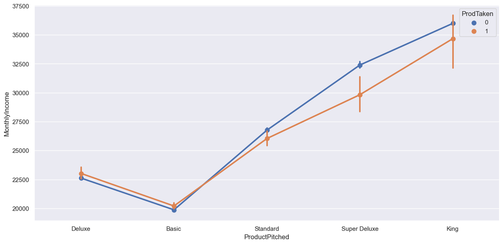

```python
plt.figure(figsize=(15, 7))
sns.pointplot(x = 'ProductPitched', y='MonthlyIncome', data=df, hue = 'ProdTaken')
```

##### Observations

- This graph is identical to the graph of pay above, meaning that individuals with the same designation were all pitched the same package with no variation
- This could have unintentional consequences for our dataset, and it may be a good idea to get more data than we currently have to account for this issue

#### PointPlot of Income, Preferred Property Star, and ProdTaken

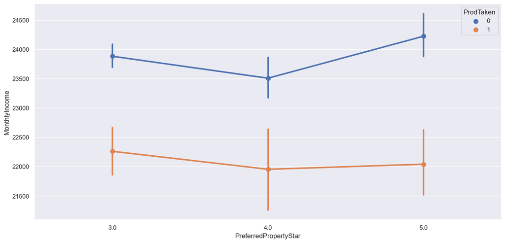

```python
plt.figure(figsize=(15, 7))
sns.pointplot(x = 'PreferredPropertyStar', y='MonthlyIncome', data=df, hue = 'ProdTaken')
```

#### PointPlot of Pitch Duration, Pitch Satisfaction, and Prod Taken

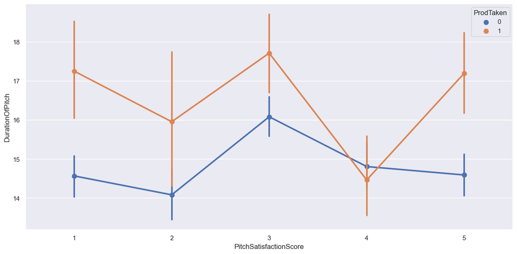

```python
plt.figure(figsize=(15, 7))
sns.pointplot(x = 'PitchSatisfactionScore', y='DurationOfPitch', data=df, hue = 'ProdTaken')
```

##### Observations

- There is a lot of variance in pitch duration for those that purchased a product, with large error bars
- The longer the pitch was, the more likely people were to purchase a product
- Four star pitches tended to be shorter and less likely to result in a product being purchased than 3 or Five

#### Pointplot of Age, Marital Status, and ProdTaken

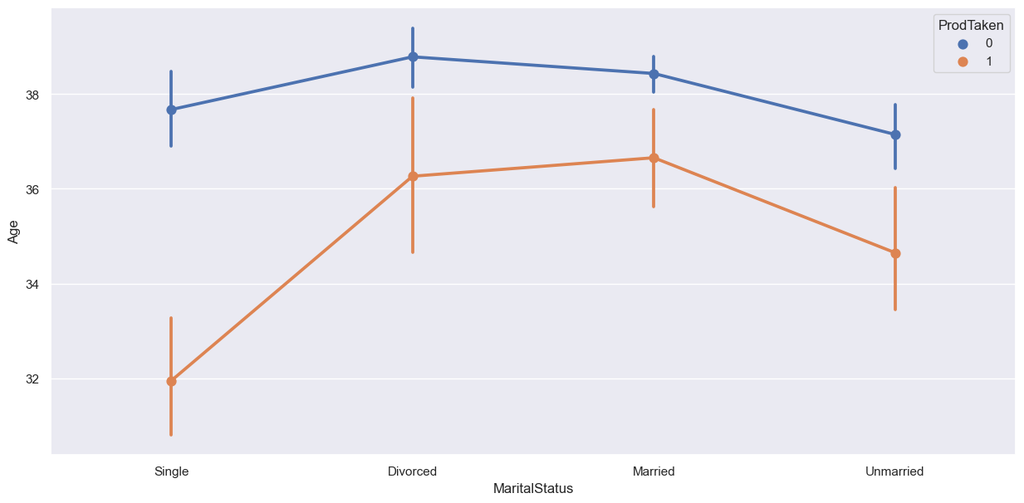

```python
plt.figure(figsize=(15, 7))
sns.pointplot(data=df, x='MaritalStatus', y='Age', hue='ProdTaken')
```

##### Observations

- Single individuals who bought packages were the youngest people in our dataset
- Each category who purchased a product was younger than those who didn't
- Divorced and married individuals were the oldest in the dataset, and those that were divorced and bought a package had the widest spread of age in the dataset

## Conclusions and Recommendations for EDA

### Predictive Strength of Columns

Features that had strong predictors for our dependent variable were:

- Product Pitched
- Marital Status
- Number of Followups
- Passport
- Designation

These are important for determining whether or not someone purchases a package from our company. There were some more moderate predictors as well such as:

- Income
- Duration of Pitch
- City Tier
- Occupation
- Preferred Property Star
- Number of Trips

These weren't as important to the end result, but still has a bearing that is worth teasing out in our model. There are some weaker columns, that aren't as important such as:

- Age
- Type of Contact
- Pitch Satisfaction Score
- Gender

These were all extremely close value wise to one another, with little spread between values. they also, like pitch satisfaction score could have values that undermine the correlation the rest of the values had presented. They could be modified, or removed without significant impact to the model. Finally we have columns that appear to have no bearing on the data whatsoever:

- Number of Children
- Own car
- Number of Person visiting

These should all be removed to prevent overfit of the model.

### NonNumeric Categories that Encoding

- Type of Contact
- Occupation
- Gender
- Product Pitched
- Marital Status
- Designation

# Feature Engineering

## Remove Unnecessary Columns

### Own Car

This had no bearing on whether or not an individual purchased a package, and should be removed due to potential model overfitting

```
ProdTaken     0    1   All
OwnCar
All        3968  920  4888
1          2472  560  3032
0          1496  360  1856
-------------------------------------------------------------------------------------------------------------------
ProdTaken         0         1
OwnCar
0          0.806034  0.193966
1          0.815303  0.184697
```

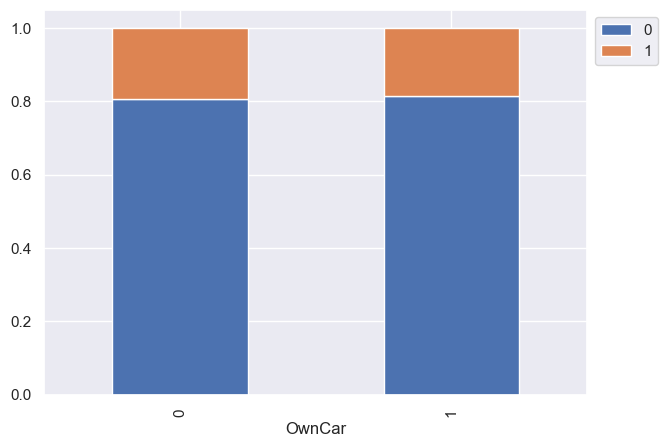

```python
stackedbarplot(df, 'OwnCar', 'ProdTaken')
```

```python
df.head(5)
```

|  | ProdTaken | Age | TypeofContact | CityTier | DurationOfPitch | Occupation | Gender | NumberOfPersonVisiting | NumberOfFollowups | ProductPitched | PreferredPropertyStar | MaritalStatus | NumberOfTrips | Passport | PitchSatisfactionScore | OwnCar | NumberOfChildrenVisiting | Designation | MonthlyIncome |
| --- | --- | --- | --- | --- | --- | --- | --- | --- | --- | --- | --- | --- | --- | --- | --- | --- | --- | --- | --- |
| 0 | 1 | 41.0 | Self Enquiry | 3 | 6.0 | Salaried | Female | 3 | 3.0 | Deluxe | 3.0 | Single | 1.0 | 1 | 2 | 1 | 0.0 | Manager | 20993.0 |
| 1 | 0 | 49.0 | Company Invited | 1 | 14.0 | Salaried | Male | 3 | 4.0 | Deluxe | 4.0 | Divorced | 2.0 | 0 | 3 | 1 | 2.0 | Manager | 20130.0 |
| 2 | 1 | 37.0 | Self Enquiry | 1 | 8.0 | Free Lancer | Male | 3 | 4.0 | Basic | 3.0 | Single | 7.0 | 1 | 3 | 0 | 0.0 | Executive | 17090.0 |
| 3 | 0 | 33.0 | Company Invited | 1 | 9.0 | Salaried | Female | 2 | 3.0 | Basic | 3.0 | Divorced | 2.0 | 1 | 5 | 1 | 1.0 | Executive | 17909.0 |
| 4 | 0 | 37.0 | Self Enquiry | 1 | 8.0 | Small Business | Male | 2 | 3.0 | Basic | 4.0 | Divorced | 1.0 | 0 | 5 | 1 | 0.0 | Executive | 18468.0 |

```python
df.drop('OwnCar', axis = 1, inplace = True)
```

```python
df.head(5)
```

|  | ProdTaken | Age | TypeofContact | CityTier | DurationOfPitch | Occupation | Gender | NumberOfPersonVisiting | NumberOfFollowups | ProductPitched | PreferredPropertyStar | MaritalStatus | NumberOfTrips | Passport | PitchSatisfactionScore | NumberOfChildrenVisiting | Designation | MonthlyIncome |
| --- | --- | --- | --- | --- | --- | --- | --- | --- | --- | --- | --- | --- | --- | --- | --- | --- | --- | --- |
| 0 | 1 | 41.0 | Self Enquiry | 3 | 6.0 | Salaried | Female | 3 | 3.0 | Deluxe | 3.0 | Single | 1.0 | 1 | 2 | 0.0 | Manager | 20993.0 |
| 1 | 0 | 49.0 | Company Invited | 1 | 14.0 | Salaried | Male | 3 | 4.0 | Deluxe | 4.0 | Divorced | 2.0 | 0 | 3 | 2.0 | Manager | 20130.0 |
| 2 | 1 | 37.0 | Self Enquiry | 1 | 8.0 | Free Lancer | Male | 3 | 4.0 | Basic | 3.0 | Single | 7.0 | 1 | 3 | 0.0 | Executive | 17090.0 |
| 3 | 0 | 33.0 | Company Invited | 1 | 9.0 | Salaried | Female | 2 | 3.0 | Basic | 3.0 | Divorced | 2.0 | 1 | 5 | 1.0 | Executive | 17909.0 |
| 4 | 0 | 37.0 | Self Enquiry | 1 | 8.0 | Small Business | Male | 2 | 3.0 | Basic | 4.0 | Divorced | 1.0 | 0 | 5 | 0.0 | Executive | 18468.0 |

### Number of Person Visiting

```
ProdTaken                  0    1   All
NumberOfPersonVisiting
All                     3968  920  4888
3                       1942  460  2402
2                       1151  267  1418
4                        833  193  1026
1                         39    0    39
5                          3    0     3
-------------------------------------------------------------------------------------------------------------------
ProdTaken                      0         1
NumberOfPersonVisiting
3                       0.808493  0.191507
2                       0.811707  0.188293
4                       0.811891  0.188109
1                       1.000000  0.000000
5                       1.000000  0.000000
```

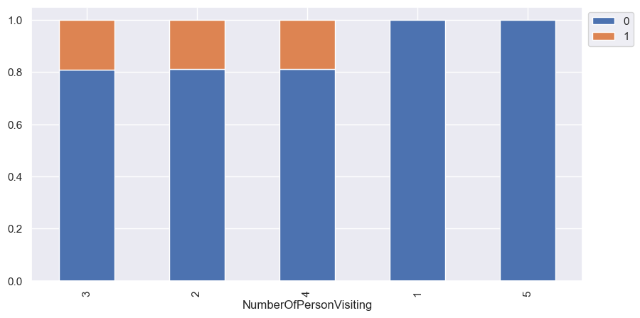

```python
stackedbarplot(df, 'NumberOfPersonVisiting', 'ProdTaken')
```

```python
df.head(5)
```

|  | ProdTaken | Age | TypeofContact | CityTier | DurationOfPitch | Occupation | Gender | NumberOfPersonVisiting | NumberOfFollowups | ProductPitched | PreferredPropertyStar | MaritalStatus | NumberOfTrips | Passport | PitchSatisfactionScore | NumberOfChildrenVisiting | Designation | MonthlyIncome |
| --- | --- | --- | --- | --- | --- | --- | --- | --- | --- | --- | --- | --- | --- | --- | --- | --- | --- | --- |
| 0 | 1 | 41.0 | Self Enquiry | 3 | 6.0 | Salaried | Female | 3 | 3.0 | Deluxe | 3.0 | Single | 1.0 | 1 | 2 | 0.0 | Manager | 20993.0 |
| 1 | 0 | 49.0 | Company Invited | 1 | 14.0 | Salaried | Male | 3 | 4.0 | Deluxe | 4.0 | Divorced | 2.0 | 0 | 3 | 2.0 | Manager | 20130.0 |
| 2 | 1 | 37.0 | Self Enquiry | 1 | 8.0 | Free Lancer | Male | 3 | 4.0 | Basic | 3.0 | Single | 7.0 | 1 | 3 | 0.0 | Executive | 17090.0 |
| 3 | 0 | 33.0 | Company Invited | 1 | 9.0 | Salaried | Female | 2 | 3.0 | Basic | 3.0 | Divorced | 2.0 | 1 | 5 | 1.0 | Executive | 17909.0 |
| 4 | 0 | 37.0 | Self Enquiry | 1 | 8.0 | Small Business | Male | 2 | 3.0 | Basic | 4.0 | Divorced | 1.0 | 0 | 5 | 0.0 | Executive | 18468.0 |

```python
df.drop('NumberOfPersonVisiting', axis = 1, inplace = True)
```

```python
df.head(5)
```

|  | ProdTaken | Age | TypeofContact | CityTier | DurationOfPitch | Occupation | Gender | NumberOfFollowups | ProductPitched | PreferredPropertyStar | MaritalStatus | NumberOfTrips | Passport | PitchSatisfactionScore | NumberOfChildrenVisiting | Designation | MonthlyIncome |
| --- | --- | --- | --- | --- | --- | --- | --- | --- | --- | --- | --- | --- | --- | --- | --- | --- | --- |
| 0 | 1 | 41.0 | Self Enquiry | 3 | 6.0 | Salaried | Female | 3.0 | Deluxe | 3.0 | Single | 1.0 | 1 | 2 | 0.0 | Manager | 20993.0 |
| 1 | 0 | 49.0 | Company Invited | 1 | 14.0 | Salaried | Male | 4.0 | Deluxe | 4.0 | Divorced | 2.0 | 0 | 3 | 2.0 | Manager | 20130.0 |
| 2 | 1 | 37.0 | Self Enquiry | 1 | 8.0 | Free Lancer | Male | 4.0 | Basic | 3.0 | Single | 7.0 | 1 | 3 | 0.0 | Executive | 17090.0 |
| 3 | 0 | 33.0 | Company Invited | 1 | 9.0 | Salaried | Female | 3.0 | Basic | 3.0 | Divorced | 2.0 | 1 | 5 | 1.0 | Executive | 17909.0 |
| 4 | 0 | 37.0 | Self Enquiry | 1 | 8.0 | Small Business | Male | 3.0 | Basic | 4.0 | Divorced | 1.0 | 0 | 5 | 0.0 | Executive | 18468.0 |

### Number of Children Visiting

This is the third column that showed no bearing on whether or not a product was purchased, and again, will be removed to prevent model overfit.

```
ProdTaken                    0    1   All
NumberOfChildrenVisiting
All                       3968  920  4888
1.0                       1747  399  2146
2.0                       1082  253  1335
0.0                        880  202  1082
3.0                        259   66   325
-------------------------------------------------------------------------------------------------------------------
ProdTaken                        0         1
NumberOfChildrenVisiting
3.0                       0.796923  0.203077
2.0                       0.810487  0.189513
0.0                       0.813309  0.186691
1.0                       0.814073  0.185927
```

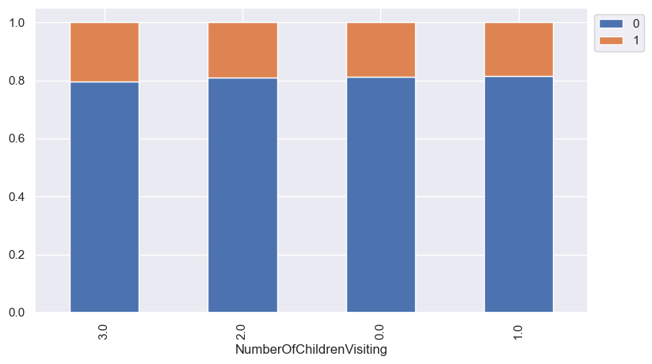

```python
stackedbarplot(df, 'NumberOfChildrenVisiting', 'ProdTaken')
```

```python
df.head(5)
```

|  | ProdTaken | Age | TypeofContact | CityTier | DurationOfPitch | Occupation | Gender | NumberOfFollowups | ProductPitched | PreferredPropertyStar | MaritalStatus | NumberOfTrips | Passport | PitchSatisfactionScore | NumberOfChildrenVisiting | Designation | MonthlyIncome |
| --- | --- | --- | --- | --- | --- | --- | --- | --- | --- | --- | --- | --- | --- | --- | --- | --- | --- |
| 0 | 1 | 41.0 | Self Enquiry | 3 | 6.0 | Salaried | Female | 3.0 | Deluxe | 3.0 | Single | 1.0 | 1 | 2 | 0.0 | Manager | 20993.0 |
| 1 | 0 | 49.0 | Company Invited | 1 | 14.0 | Salaried | Male | 4.0 | Deluxe | 4.0 | Divorced | 2.0 | 0 | 3 | 2.0 | Manager | 20130.0 |
| 2 | 1 | 37.0 | Self Enquiry | 1 | 8.0 | Free Lancer | Male | 4.0 | Basic | 3.0 | Single | 7.0 | 1 | 3 | 0.0 | Executive | 17090.0 |
| 3 | 0 | 33.0 | Company Invited | 1 | 9.0 | Salaried | Female | 3.0 | Basic | 3.0 | Divorced | 2.0 | 1 | 5 | 1.0 | Executive | 17909.0 |
| 4 | 0 | 37.0 | Self Enquiry | 1 | 8.0 | Small Business | Male | 3.0 | Basic | 4.0 | Divorced | 1.0 | 0 | 5 | 0.0 | Executive | 18468.0 |

```python
df.drop('NumberOfChildrenVisiting', axis = 1, inplace = True)
```

```python
df.head(5)
```

|  | ProdTaken | Age | TypeofContact | CityTier | DurationOfPitch | Occupation | Gender | NumberOfFollowups | ProductPitched | PreferredPropertyStar | MaritalStatus | NumberOfTrips | Passport | PitchSatisfactionScore | Designation | MonthlyIncome |
| --- | --- | --- | --- | --- | --- | --- | --- | --- | --- | --- | --- | --- | --- | --- | --- | --- |
| 0 | 1 | 41.0 | Self Enquiry | 3 | 6.0 | Salaried | Female | 3.0 | Deluxe | 3.0 | Single | 1.0 | 1 | 2 | Manager | 20993.0 |
| 1 | 0 | 49.0 | Company Invited | 1 | 14.0 | Salaried | Male | 4.0 | Deluxe | 4.0 | Divorced | 2.0 | 0 | 3 | Manager | 20130.0 |
| 2 | 1 | 37.0 | Self Enquiry | 1 | 8.0 | Free Lancer | Male | 4.0 | Basic | 3.0 | Single | 7.0 | 1 | 3 | Executive | 17090.0 |
| 3 | 0 | 33.0 | Company Invited | 1 | 9.0 | Salaried | Female | 3.0 | Basic | 3.0 | Divorced | 2.0 | 1 | 5 | Executive | 17909.0 |
| 4 | 0 | 37.0 | Self Enquiry | 1 | 8.0 | Small Business | Male | 3.0 | Basic | 4.0 | Divorced | 1.0 | 0 | 5 | Executive | 18468.0 |

### Pitch Satisfaction Score

We have two columns, pitch duration and pitch satisfaction score that describe an individual pitch. While Pitch Satisfaction score could be useful, 3 and 5 both have a larger number of takers than 4, and Pitch Duration tends to show a stronger correlation with ProdTaken than Pitch Satisfaction does. This may negatively affect a model down the road, but we do not have the background to know for sure.

```
ProdTaken                  0    1   All
PitchSatisfactionScore
All                     3968  920  4888
3                       1162  316  1478
5                        760  210   970
4                        750  162   912
1                        798  144   942
2                        498   88   586
-------------------------------------------------------------------------------------------------------------------
ProdTaken                      0         1
PitchSatisfactionScore
5                       0.783505  0.216495
3                       0.786198  0.213802
4                       0.822368  0.177632
1                       0.847134  0.152866
2                       0.849829  0.150171
```

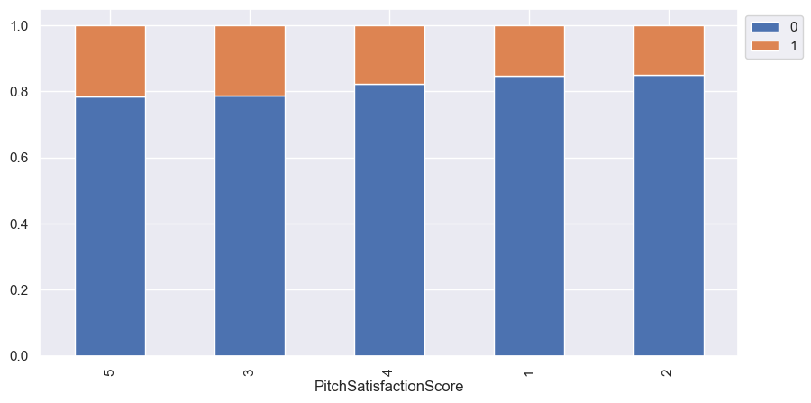

```python
stackedbarplot(df, 'PitchSatisfactionScore', 'ProdTaken')
```

```python
df.head(5)
```

|  | ProdTaken | Age | TypeofContact | CityTier | DurationOfPitch | Occupation | Gender | NumberOfFollowups | ProductPitched | PreferredPropertyStar | MaritalStatus | NumberOfTrips | Passport | PitchSatisfactionScore | Designation | MonthlyIncome |
| --- | --- | --- | --- | --- | --- | --- | --- | --- | --- | --- | --- | --- | --- | --- | --- | --- |
| 0 | 1 | 41.0 | Self Enquiry | 3 | 6.0 | Salaried | Female | 3.0 | Deluxe | 3.0 | Single | 1.0 | 1 | 2 | Manager | 20993.0 |
| 1 | 0 | 49.0 | Company Invited | 1 | 14.0 | Salaried | Male | 4.0 | Deluxe | 4.0 | Divorced | 2.0 | 0 | 3 | Manager | 20130.0 |
| 2 | 1 | 37.0 | Self Enquiry | 1 | 8.0 | Free Lancer | Male | 4.0 | Basic | 3.0 | Single | 7.0 | 1 | 3 | Executive | 17090.0 |
| 3 | 0 | 33.0 | Company Invited | 1 | 9.0 | Salaried | Female | 3.0 | Basic | 3.0 | Divorced | 2.0 | 1 | 5 | Executive | 17909.0 |
| 4 | 0 | 37.0 | Self Enquiry | 1 | 8.0 | Small Business | Male | 3.0 | Basic | 4.0 | Divorced | 1.0 | 0 | 5 | Executive | 18468.0 |

```python
df.drop('PitchSatisfactionScore', axis = 1, inplace = True)
```

```python
df.head(5)
```

|  | ProdTaken | Age | TypeofContact | CityTier | DurationOfPitch | Occupation | Gender | NumberOfFollowups | ProductPitched | PreferredPropertyStar | MaritalStatus | NumberOfTrips | Passport | Designation | MonthlyIncome |
| --- | --- | --- | --- | --- | --- | --- | --- | --- | --- | --- | --- | --- | --- | --- | --- |
| 0 | 1 | 41.0 | Self Enquiry | 3 | 6.0 | Salaried | Female | 3.0 | Deluxe | 3.0 | Single | 1.0 | 1 | Manager | 20993.0 |
| 1 | 0 | 49.0 | Company Invited | 1 | 14.0 | Salaried | Male | 4.0 | Deluxe | 4.0 | Divorced | 2.0 | 0 | Manager | 20130.0 |
| 2 | 1 | 37.0 | Self Enquiry | 1 | 8.0 | Free Lancer | Male | 4.0 | Basic | 3.0 | Single | 7.0 | 1 | Executive | 17090.0 |
| 3 | 0 | 33.0 | Company Invited | 1 | 9.0 | Salaried | Female | 3.0 | Basic | 3.0 | Divorced | 2.0 | 1 | Executive | 17909.0 |
| 4 | 0 | 37.0 | Self Enquiry | 1 | 8.0 | Small Business | Male | 3.0 | Basic | 4.0 | Divorced | 1.0 | 0 | Executive | 18468.0 |

## Clean up and Consolidate labels in Categorical featues

### Occupation

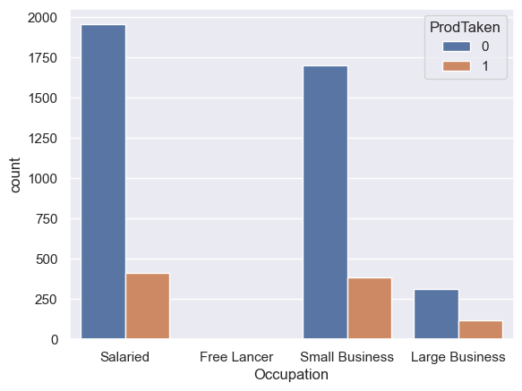

```python
sns.countplot(data= df, x='Occupation', hue = 'ProdTaken')
```

Freelancer is a statistically insignificant amount of data, and so we decided to drop it. It could negatively affect our data, and we wanted to ensure that our model didn't assume every Freelancer was going to purchase a package

```python
df.drop(df[(df['Occupation'] == 'Free Lancer')].index, inplace=True)
```

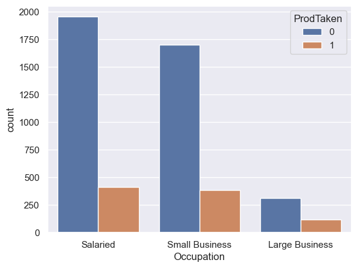

```python
sns.countplot(data= df, x='Occupation', hue = 'ProdTaken')
```